# Análise | Geradora

### Verificando se essa unidade geradora se adequa aos padrões de qualidade do PRODIST.

```python
import pandas as pd
import seaborn as sns
import matplotlib.pyplot as plt
import matplotlib.dates as mdates
import warnings

# Define o nível de aviso como "ignore"
warnings.filterwarnings("ignore")
```

```python
datasheet = pd.read_csv(r'D:\repositorios git\HVEX\dados\DataSheet_3421198001_3P4W.csv',
                        sep=';', encoding='UTF-8')
```

*É uma prática comum em pandas deixar a coluna de data como índice (index) do dataframe. Isso porque, ao trabalhar com dados de séries temporais, é muito comum que a análise envolva operações de agregação, resampling e plotagem com base nas datas.*

```python
datasheet.index = pd.to_datetime(datasheet['Datetime'], format='%d/%m/%Y %H:%M:%S')
```

```python
datasheet.shape
```

```
(10080, 74)
```

```python
datasheet.describe()
```

|  | UA | UB | UC | UAvg | UN | UTHDA | UTHDB | UTHDC | UTHDAvg | IA | ... | PDmIA | PDmIB | PDmIC | PDmIAVG | DmP | PDmP | DmQ | PDmQ | DmS | PDmS |
| --- | --- | --- | --- | --- | --- | --- | --- | --- | --- | --- | --- | --- | --- | --- | --- | --- | --- | --- | --- | --- | --- |
| count | 10080.000000 | 10080.000000 | 10080.000000 | 10080.000000 | 10080.0 | 10080.000000 | 10080.000000 | 10080.000000 | 10080.000000 | 10080.000000 | ... | 10080.000000 | 10080.000000 | 10080.000000 | 10080.000000 | 10080.000000 | 10080.0 | 10080.000000 | 10080.000000 | 10080.000000 | 10080.000000 |
| mean | 125.832443 | 126.704181 | 123.366787 | 125.301145 | 0.0 | 2.306172 | 2.371813 | 2.353044 | 2.343678 | 115.158444 | ... | 227.098815 | 224.598766 | 243.311764 | 230.762126 | -41187.893510 | 0.0 | 18678.477243 | 41801.757497 | 45522.178868 | 85271.789035 |
| std | 16.556721 | 16.622652 | 16.199787 | 16.440907 | 0.0 | 0.506675 | 0.444520 | 0.469185 | 0.446814 | 46.913059 | ... | 44.598743 | 38.796647 | 49.622248 | 44.891680 | 15362.548904 | 0.0 | 8714.268801 | 8571.092851 | 17463.740451 | 16215.164011 |
| min | 0.000000 | 0.000000 | 0.000000 | 0.000000 | 0.0 | 0.000000 | 0.000000 | 0.000000 | 0.000000 | 0.000000 | ... | 97.740000 | 115.410000 | 103.520000 | 104.240000 | -79595.480000 | 0.0 | -25.740000 | 16111.480000 | 0.000000 | 39567.020000 |
| 25% | 126.920000 | 127.690000 | 124.280000 | 126.380000 | 0.0 | 2.102000 | 2.183000 | 2.112000 | 2.157000 | 81.010000 | ... | 242.960000 | 237.670000 | 259.570000 | 246.730000 | -51372.322500 | 0.0 | 11650.685000 | 44847.040000 | 31285.120000 | 91039.470000 |
| 50% | 128.070000 | 128.880000 | 125.440000 | 127.500000 | 0.0 | 2.313000 | 2.391000 | 2.361000 | 2.358500 | 117.995000 | ... | 242.960000 | 237.670000 | 259.570000 | 246.730000 | -41871.535000 | 0.0 | 19574.540000 | 44847.040000 | 46618.895000 | 91039.470000 |
| 75% | 129.220000 | 130.010000 | 126.600000 | 128.590000 | 0.0 | 2.545000 | 2.606000 | 2.643000 | 2.587000 | 147.730000 | ... | 242.960000 | 239.850000 | 263.710000 | 246.730000 | -29025.717500 | 0.0 | 24369.185000 | 44847.040000 | 57116.892500 | 91039.470000 |
| max | 140.800000 | 140.960000 | 133.280000 | 138.350000 | 0.0 | 23.581000 | 12.831000 | 7.118000 | 13.744000 | 350.450000 | ... | 242.960000 | 239.850000 | 263.710000 | 246.730000 | 0.000000 | 0.0 | 44847.040000 | 44847.040000 | 91039.470000 | 91039.470000 |

8 rows × 64 columns

Pela tabela acima podemos perceber que a instalação que gera no nivel de 127V. Também é possivel notar que houve uma interrupção visto que existe um mínimo igual a zero.

No Brasil, por exemplo, a ANEEL (Agência Nacional de Energia Elétrica) estabelece que a tensão fornecida pelas concessionárias deve estar dentro dos seguintes limites:

- Tensão nominal de fornecimento: 127V ou 220V
- Tolerância de variação da tensão: +/- 6% para mais ou para menos em relação à tensão nominal.

Isso significa que a tensão fornecida pode variar dentro de uma faixa de +/- 7,62V para uma tensão nominal de 127V.A

ANEEL também estabelece que a concessionária de energia elétrica deve manter a tensão elétrica dentro dos limites estabelecidos por pelo menos 95% do tempo em um período de um mês. Como nossa amostra é de uma semana não tem como avaliarmos.

## Analise geral

```python
datasheet.columns
```

```
Index(['Date', 'Time', 'UA', 'UB', 'UC', 'UAvg', 'UN', 'UTHDA', 'UTHDB',
       'UTHDC', 'UTHDAvg', 'IA', 'IB', 'IC', 'IAvg', 'IN', 'ITHDA', 'ITHDB',
       'ITHDC', 'ITHDAvg', 'FA', 'FB', 'FC', 'FAvg', 'PFA', 'PFB', 'PFC',
       'PFTotal', 'PA', 'PB', 'PC', 'PSum', 'QA', 'QB', 'QC', 'QSum', 'SA',
       'SB', 'SC', 'SSum', 'EPA', 'EPB', 'EPC', 'EPSum', 'EQA', 'EQB', 'EQC',
       'EQSum', 'ESA', 'ESB', 'ESC', 'ESSum', 'DmIA', 'DmIB', 'DmIC', 'DmIAVG',
       'PDmIA', 'PDmIA_D/T', 'PDmIB', 'PDmIB_D/T', 'PDmIC', 'PDmIC_D/T',
       'PDmIAVG', 'PDmIAVG_D/T', 'DmP', 'PDmP', 'PDmP_D/T', 'DmQ', 'PDmQ',
       'PDmQ_D/T', 'DmS', 'PDmS', 'PDmS_D/T', 'Datetime'],
      dtype='object')
```

## Análise da tensão (U)

```python
# Separando a parte de tensão em outra variavel para facilitar a leitura do código
voltage = datasheet[['Date',  'UA', 'UB', 'UC', 'UAvg', 'UN',
                     'UTHDA', 'UTHDB', 'UTHDC', 'UTHDAvg']]
voltage.head()
```

| Datetime | Date | UA | UB | UC | UAvg | UN | UTHDA | UTHDB | UTHDC | UTHDAvg |
| --- | --- | --- | --- | --- | --- | --- | --- | --- | --- | --- |
| 2022-03-28 00:00:00 | 28/03/2022 | 129.70 | 128.93 | 125.15 | 127.93 | 0.0 | 2.137 | 2.389 | 2.665 | 2.397 |
| 2022-03-28 00:01:00 | 28/03/2022 | 129.31 | 128.67 | 124.72 | 127.57 | 0.0 | 2.055 | 2.295 | 2.517 | 2.289 |
| 2022-03-28 00:02:00 | 28/03/2022 | 129.79 | 129.12 | 124.52 | 127.81 | 0.0 | 2.258 | 2.335 | 2.677 | 2.423 |
| 2022-03-28 00:03:00 | 28/03/2022 | 130.09 | 129.53 | 124.65 | 128.09 | 0.0 | 2.363 | 2.414 | 2.860 | 2.546 |
| 2022-03-28 00:04:00 | 28/03/2022 | 130.12 | 129.74 | 124.84 | 128.23 | 0.0 | 2.326 | 2.421 | 2.740 | 2.496 |

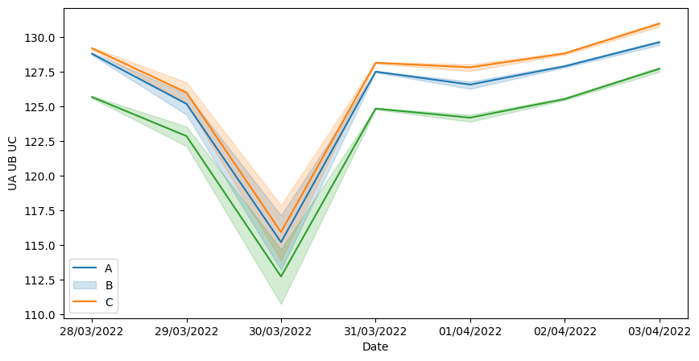

```python
# Plotando as tensões médias por dia (para plotar sem agregação)
plt.figure(figsize=(10,5))
plt.ylabel('UA UB UC')
sns.lineplot(x = voltage['Date'], y='UA', data=voltage)
sns.lineplot(x = voltage['Date'], y='UB', data=voltage)
sns.lineplot(x = voltage['Date'], y='UC', data=voltage)
plt.legend(labels=['A', 'B', 'C'])
```

Observando o grafico acima podemos tirar as seguintes conclusões:

- De acordo com o grafico acima podemos entender que dia 30/03 tivemos uma queda na tensão (média).
- Ainda podemos notar que as fases não estão idealmente balanceadas por se tratar de um sistema não ideal.

Será que o desbalanceamento das cargas, as oscilações de tensões, e niveis harmonicos estão em conforme a resolução PRODIST?

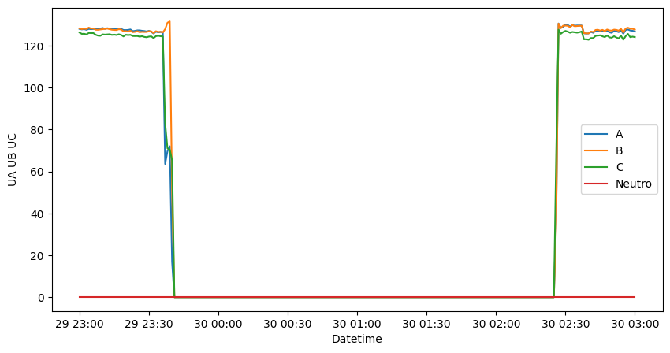

```python
# Seleciona apenas as leituras de voltagem dentro de um intervalo de tempo específico
voltage_cut = voltage[(voltage.index >= '29/03/2022 23:0:00') & (voltage.index <= '30/03/2022 03:00:00')]

# Cria um dataframe com os dados selecionados e extrai a coluna de datas
df = voltage_cut
column = df.index

# Define o tamanho da figura e o rótulo do eixo y
plt.figure(figsize=(10,5))
plt.ylabel('UA UB UC')

# Plota cada coluna de voltagem em um gráfico separado, com as datas no eixo x
sns.lineplot(x = column, y='UA', data=df, estimator=None)
sns.lineplot(x = column, y='UB', data=df, estimator=None)
sns.lineplot(x = column, y='UC', data=df, estimator=None)

# Adiciona um gráfico adicional para a voltagem neutra
sns.lineplot(x = column, y='UN', data=df, estimator=None)

# Adiciona uma legenda para cada linha no gráfico
plt.legend(labels=['A', 'B', 'C', 'Neutro'])
```

Observando o recorte da noite entre 29/03 e 30/03 chegamos a conclusão:

- Ouve uma falta entre as 23 horas do dia 29 e as 2 horas do dia 30

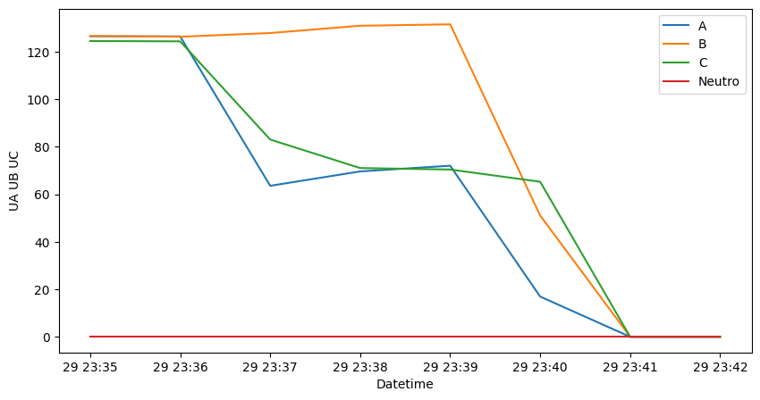

```python
# Seleciona apenas as leituras de voltagem dentro de um intervalo de tempo específico
voltage_cut = voltage[(voltage.index >= '29/03/2022 23:35:00') & (voltage.index <= '29/03/2022 23:42:00')]

# Cria um dataframe com os dados selecionados e extrai a coluna de datas
df = voltage_cut
column = df.index

# Define o tamanho da figura e o rótulo do eixo y
plt.figure(figsize=(10,5))
plt.ylabel('UA UB UC')

# Plota cada coluna de voltagem em um gráfico separado, com as datas no eixo x
sns.lineplot(x = column, y='UA', data=df, estimator=None)
sns.lineplot(x = column, y='UB', data=df, estimator=None)
sns.lineplot(x = column, y='UC', data=df, estimator=None)

# Adiciona um gráfico adicional para a voltagem neutra
sns.lineplot(x = column, y='UN', data=df, estimator=None)

# Adiciona uma legenda para cada linha no gráfico
plt.legend(labels=['A', 'B', 'C', 'Neutro'])
```

### Possiveis causas:

- Problema em um transformador ou linha que alimenta essas fases, enquanto a queda na fase B pode ter ocorrido porque o transformador ou linha que alimenta essa fase estava sobrecarregado devido à falta de energia nas outras fases.
- Outra possibilidade é que a queda de tensão tenha sido causada por um problema em um dos equipamentos elétricos conectados ao sistema elétrico que causou um desequilíbrio nas fases.

Para tirar conclusões mais precisas, é importante analisar os dados com mais detalhes e realizar testes adicionais para identificar a causa raiz da falha.

```python
voltage_frame = voltage[(voltage.index >= '29/03/2022 23:35:00') & (voltage.index <= '29/03/2022 23:42:00')]
voltage_frame[voltage_frame['UA'] == 0].index.max() - voltage_frame[voltage_frame['UA'] == 0].index.min()
```

```
Timedelta('0 days 00:01:00')
```

# Analise da Corrente (I)

```python
current = datasheet[['Date', 'IA', 'IB', 'IC', 'IN', 'IAvg', 'ITHDAvg']]
current.head()
```

| Datetime | Date | IA | IB | IC | IN | IAvg | ITHDAvg |
| --- | --- | --- | --- | --- | --- | --- | --- |
| 2022-03-28 00:00:00 | 28/03/2022 | 62.48 | 69.14 | 73.45 | 2.82 | 68.36 | 4.725 |
| 2022-03-28 00:01:00 | 28/03/2022 | 64.99 | 70.88 | 76.50 | 2.62 | 70.79 | 4.707 |
| 2022-03-28 00:02:00 | 28/03/2022 | 64.50 | 69.04 | 76.38 | 2.69 | 69.98 | 4.781 |
| 2022-03-28 00:03:00 | 28/03/2022 | 62.57 | 67.34 | 74.51 | 2.83 | 68.14 | 5.117 |
| 2022-03-28 00:04:00 | 28/03/2022 | 65.84 | 69.42 | 76.33 | 2.71 | 70.53 | 4.867 |

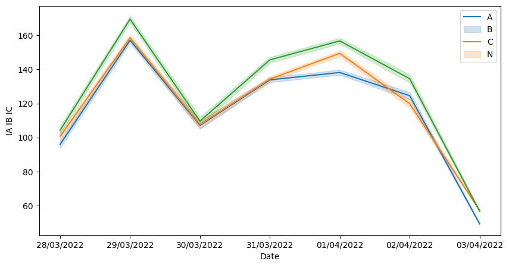

```python
plt.figure(figsize=(10,5))
plt.ylabel('IA IB IC')
sns.lineplot(x = current['Date'], y='IA', data=current)
sns.lineplot(x = current['Date'], y='IB', data=current)
sns.lineplot(x = current['Date'], y='IC', data=current)
plt.legend(labels=['A', 'B', 'C', 'N'])
```

Como a corrente depende da carga ele é mais varivel com o tempo, fatores sazionais podem modificar o consumo, como:

- Fim de semana ou inicio de semana
- Tipo de instalação (setor de operação)

O espaço de tempo de nossa analise se trata de uma semana (segunda a domingo).

- É possivel notar um pico de corrente na terça e sexta indicando dias de maior "produção"

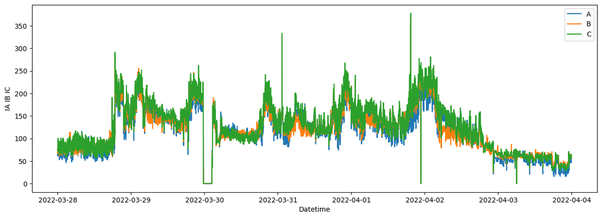

```python
df = current
column = df.index

plt.figure(figsize=(15,5))
plt.ylabel('IA IB IC')
sns.lineplot(x = column, y='IA', data=df, estimator=None)
sns.lineplot(x = column, y='IB', data=df, estimator=None)
sns.lineplot(x = column, y='IC', data=df, estimator=None)
plt.legend(labels=['A', 'B', 'C'])
```

### Análise da corrente de neutro IN

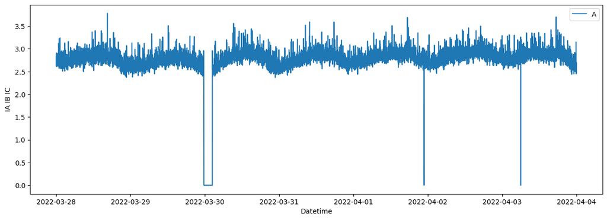

```python
df = current
column = df.index

plt.figure(figsize=(15,5))
plt.ylabel('IA IB IC')
sns.lineplot(x = column, y='IN', data=df, estimator=None)
plt.legend(labels=['A', 'B', 'C'])
```

De acordo com a norma brasileira NBR 5410:2004 - Instalações elétricas de baixa tensão, em uma instalação trifásica equilibrada, a corrente de neutro deve ser igual a zero. No entanto, em algumas situações, como em sistemas desequilibrados ou com cargas não lineares, pode haver presença de corrente de neutro.

A norma não estabelece um valor máximo para a corrente de neutro em uma instalação trifásica, mas recomenda que a corrente de neutro não ultrapasse 30% da corrente nominal das fases. Caso isso ocorra, pode ser necessário investigar a causa da corrente de neutro elevada e adotar medidas corretivas para evitar danos ao sistema elétrico ou equipamentos conectados.

Agora vamos investigar se a corrente de neutro ultrapassa os limites.

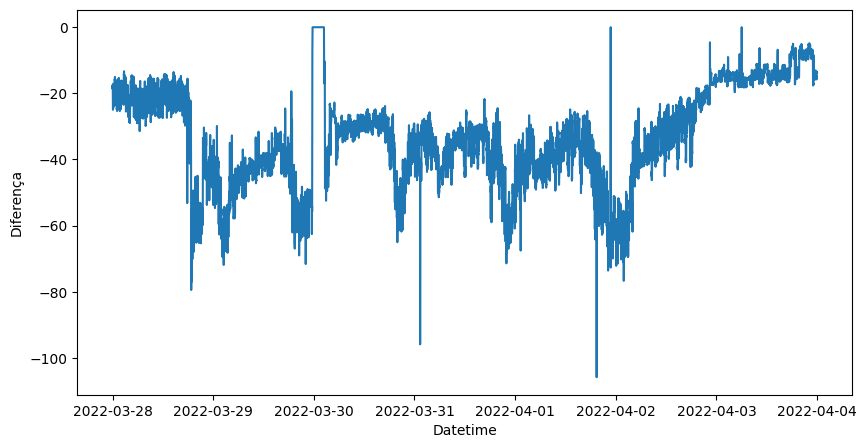

```python
# Calcula 30% da coluna IAVG
limite = 0.3 * current['IAvg']

# Cria uma nova coluna chamada 'IN dentro do limite' com valores True ou False,
# indicando se a coluna IN é menor ou igual a 30% da coluna IAVG
df = current
df['IN dentro do limite'] = df['IN'] - limite

# Exibe o resultado
plt.figure(figsize=(10,5))
plt.ylabel('Diferença')
sns.lineplot(x = column, y='IN dentro do limite', data=df, estimator=None)
```

Como os valores não ultrapassam zero quer dizer que os valores de neutro estão dentro das normas.

## Análise de Conformidade Prodist 8

Existe requisitos mínimos para a qualidade da energia elétrica estabelecidos pelo Módulo 8 do PRODIST. Agora será analisado se essa usina atende.

- Distorção Harmônica Total (DHT): é um parâmetro que indica a presença de harmônicos na forma de onda da tensão ou corrente elétrica. O Módulo 8 estabelece que o valor máximo permitido para DHT na tensão elétrica deve ser inferior a 3% em condições normais de operação.

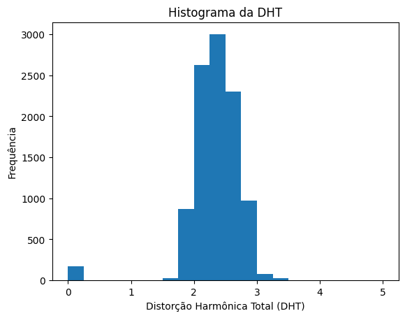

```
A DHT está dentro dos limites do PRODIST.
```

```python
# Plotando um histograma da DHT
plt.hist(datasheet['UTHDAvg'], bins=20, range=(0, 5))
plt.xlabel('Distorção Harmônica Total (DHT)')
plt.ylabel('Frequência')
plt.title('Histograma da DHT')
plt.show()

# Calculando a média e o desvio padrão da DHT
media_DHT = datasheet['UTHDAvg'].mean()
desvio_DHT = datasheet['UTHDAvg'].std()

# Verificando se a DHT está dentro dos limites do PRODIST
if media_DHT <= 3 and desvio_DHT <= 1:
    print('A DHT está dentro dos limites do PRODIST.')
else:
    print('A DHT não está dentro dos limites do PRODIST.')
```

- Fator de Potência: o Módulo 8 estabelece que o fator de potência não deve ser inferior a 0,92 para geradores com potência superior a 75 kW, ou inferior a 0,95 para geradores com potência inferior a 75 kW.

```python
fatPot = datasheet[['PFA', 'PFB', 'PFC', 'PFTotal']]
fatPot.describe()[:3]
```

|  | PFA | PFB | PFC | PFTotal |
| --- | --- | --- | --- | --- |
| count | 10080.000000 | 10080.000000 | 10080.000000 | 10080.000000 |
| mean | -0.916858 | -0.877353 | -0.891823 | -0.895068 |
| std | 0.126955 | 0.120153 | 0.125721 | 0.121050 |

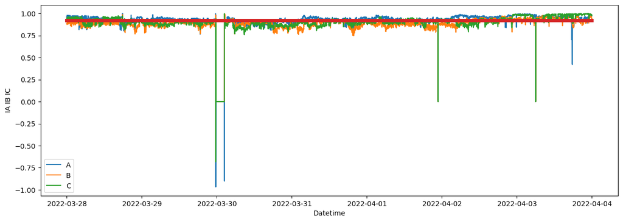

```python
fatPot['PFlim'] = [(0.92) for i in range(0, len(fatPot['PFA']))]

fatPot['PFA'] = fatPot['PFA']*(-1)
fatPot['PFB'] = fatPot['PFB']*(-1)
fatPot['PFC'] = fatPot['PFC']*(-1)

plt.figure(figsize=(15,5))
plt.ylabel('IA IB IC')
sns.lineplot(x = fatPot.index, y='PFA', data=fatPot, estimator=None)
sns.lineplot(x = fatPot.index, y='PFB', data=fatPot, estimator=None)
sns.lineplot(x = fatPot.index, y='PFC', data=fatPot, estimator=None)
sns.lineplot(x = fatPot.index, y='PFlim', data=fatPot, estimator=None, linewidth=5)
plt.legend(labels=['A', 'B', 'C'])
```

### A linha vermelha que indica o minimo valor permitido de fator de potência. Como podemos observar em grande parte do tempo a instalação tem um fator de potencia menor que o esperado pela norma.

### Açoes:

- Instalar capacitores: Os capacitores são dispositivos que armazenam energia elétrica e ajudam a corrigir o fator de potência. Ao instalar capacitores na usina, é possível melhorar o fator de potência e reduzir a demanda por energia reativa.
- Revisar os equipamentos: Equipamentos elétricos com baixo rendimento podem contribuir para um fator de potência baixo. Revisar os equipamentos e substituir aqueles com baixo rendimento pode ajudar a melhorar o fator de potência.
- Redimensionar o transformador: Transformadores superdimensionados podem contribuir para um fator de potência baixo. Redimensionar o transformador de acordo com a demanda real da usina pode ajudar a melhorar o fator de potência.
- Reduzir o consumo de energia reativa: Algumas cargas elétricas consomem energia reativa, o que pode contribuir para um fator de potência baixo. Reduzir o consumo de energia reativa por meio de medidas como o uso de lâmpadas fluorescentes ou de LED, por exemplo, pode ajudar a melhorar o fator de potência.

#### No desenvolvimento desse notebook jupyter discutimos sobre a qualidade da energia elétrica e como ela é regulamentada pelo PRODIST. Vimos que existem diversos requisitos mínimos a serem atendidos, como a distorção harmônica total, oscilação de tensão e interrupção de fornecimento. Também discutimos sobre o fator de potência e como ele é importante para o desempenho de uma usina. Por fim, vimos algumas ações que podem ser tomadas para corrigir o fator de potência caso ele esteja abaixo do permitido. É fundamental que as empresas estejam cientes dessas questões e adotem medidas para garantir que a qualidade da energia elétrica atenda aos requisitos do PRODIST, garantindo um fornecimento de energia seguro e confiável para todos.